# Bank Customers Credit Risk Analysis

## R Markdown

### Data Propocess

```r
mydf <- read.csv("/Users/yx921121/Documents/GWU/2017Fall/Programming/Assignment/Logistics Regression/creditdata.csv")  #input data
```

```r
sum(is.na(mydf))        #check if there are null
```

```
## [1] 0
```

```r
mydf[mydf==""]  <- NA    #check if there are blank space so that make sure the data is clean
sum(is.na(mydf))
```

```
## [1] 0
```

```r
sum(!complete.cases(mydf))
```

```
## [1] 0
```

```r
sapply(mydf, function(x) sum(is.na(x)))
```

```
##     rating experience    homeown   loandurn        age      mstat
##          0          0          0          0          0          0
##       rcds      jtype     explvl        inc      assts       debt
##          0          0          0          0          0          0
## loanamount purchprice
##          0          0
```

```r
mydf$rating <- as.numeric(mydf$rating)
mydf$homeown <- as.numeric(mydf$homeown)
mydf$mstat <- as.numeric(mydf$mstat)
mydf$jtype <- as.numeric(mydf$jtype)
```

```r
head(mydf$rating)
```

```
## [1] 2 2 1 2 2 2
```

```r
#Convert these values to 0 and 1
mydf$rating <- ifelse(mydf$rating == 1, 0, 1)
```

```r
head(mydf$rating)
```

```
## [1] 1 1 0 1 1 1
```

```r
#Variables and their types
sapply(mydf, class)
```

```
##     rating experience    homeown   loandurn        age      mstat
##  "numeric"  "integer"  "numeric"  "integer"  "integer"  "numeric"
##       rcds      jtype     explvl        inc      assts       debt
##   "factor"  "numeric"  "integer"  "integer"  "integer"  "integer"
## loanamount purchprice
##  "integer"  "integer"
```

```r
nrow(mydf)    #view how many rows
```

```
## [1] 4446
```

```r
mydf_train <- mydf[c(1:2223),]   #subset the first half of data as the training set
mydf_test <- mydf[c(2224:4446),]       #subset the second half of data as the test set
```

```r
str(mydf_train)    #to view variables and types
```

```
## 'data.frame':    2223 obs. of  14 variables:
##  $ rating    : num  1 1 0 1 1 1 1 1 1 0 ...
##  $ experience: int  9 17 10 0 0 1 29 9 0 0 ...
##  $ homeown   : num  6 6 3 6 6 3 3 4 3 4 ...
##  $ loandurn  : int  60 60 36 60 36 60 60 12 60 48 ...
##  $ age       : int  30 58 46 24 26 36 44 27 32 41 ...
##  $ mstat     : num  2 5 2 4 4 2 2 4 2 2 ...
##  $ rcds      : Factor w/ 2 levels "no_rec","yes_rec": 1 1 2 1 1 1 1 1 1 1 ...
##  $ jtype     : num  2 1 2 1 1 1 1 1 2 4 ...
##  $ explvl    : int  73 48 90 63 46 75 75 35 90 90 ...
##  $ inc       : int  129 131 200 182 107 214 125 80 107 80 ...
##  $ assts     : int  0 0 3000 2500 0 3500 10000 0 15000 0 ...
##  $ debt      : int  0 0 0 0 0 0 0 0 0 0 ...
##  $ loanamount: int  800 1000 2000 900 310 650 1600 200 1200 1200 ...
##  $ purchprice: int  846 1658 2985 1325 910 1645 1800 1093 1957 1468 ...
```

### Data Exploration

```r
#make descriptive stats
table(mydf_train$rating)
```

```
##
##    0    1
##  628 1595
```

```r
table(mydf_train$homeown)
```

```
##
##    1    2    3    4    5    6
##    9  160 1072  362  104  516
```

```r
table(mydf_train$mstat)
```

```
##
##    1    2    3    4    5
##   20 1647   59  463   34
```

```r
table(mydf_train$rcds)
```

```
##
##  no_rec yes_rec
##    1896     327
```

```r
table(mydf_train$jtype)
```

```
##
##    1    2    3    4
## 1413  535   72  203
```

```r
summary(mydf_train$experience)
```

```
##    Min. 1st Qu.  Median    Mean 3rd Qu.    Max.
##   0.000   2.000   5.000   7.853  12.000  43.000
```

```r
summary(mydf_train$loandurn)
```

```
##    Min. 1st Qu.  Median    Mean 3rd Qu.    Max.
##    6.00   36.00   48.00   46.36   60.00   60.00
```

```r
summary(mydf_train$age)
```

```
##    Min. 1st Qu.  Median    Mean 3rd Qu.    Max.
##   18.00   28.00   35.00   37.07   45.00   68.00
```

```r
summary(mydf_train$explvl)
```

```
##    Min. 1st Qu.  Median    Mean 3rd Qu.    Max.
##   35.00   45.00   60.00   60.91   75.00  173.00
```

```r
summary(mydf_train$inc)
```

```
##    Min. 1st Qu.  Median    Mean 3rd Qu.    Max.
##     1.0    93.0   130.0   148.6   180.0   959.0
```

```r
summary(mydf_train$assts)
```

```
##    Min. 1st Qu.  Median    Mean 3rd Qu.    Max.
##       0       0    3000    5467    6000  300000
```

```r
summary(mydf_train$debt)
```

```
##    Min. 1st Qu.  Median    Mean 3rd Qu.    Max.
##     0.0     0.0     0.0   353.8     0.0 30000.0
```

```r
summary(mydf_train$loanamount)
```

```
##    Min. 1st Qu.  Median    Mean 3rd Qu.    Max.
##     100     700    1000    1028    1300    5000
```

```r
summary(mydf_train$purchprice)
```

```
##    Min. 1st Qu.  Median    Mean 3rd Qu.    Max.
##     105    1111    1386    1440    1683    8800
```

```r
library("ggplot2")
```

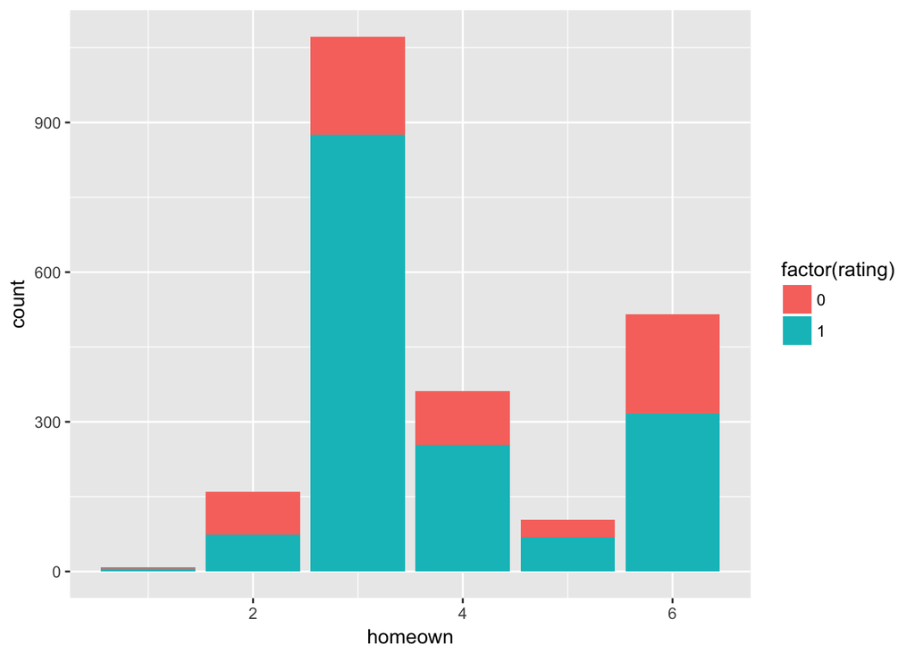

```r
#plot discrete~discrete variables using bar
ggplot(mydf_train, aes(homeown)) + geom_bar(aes(fill=factor(rating)))
```

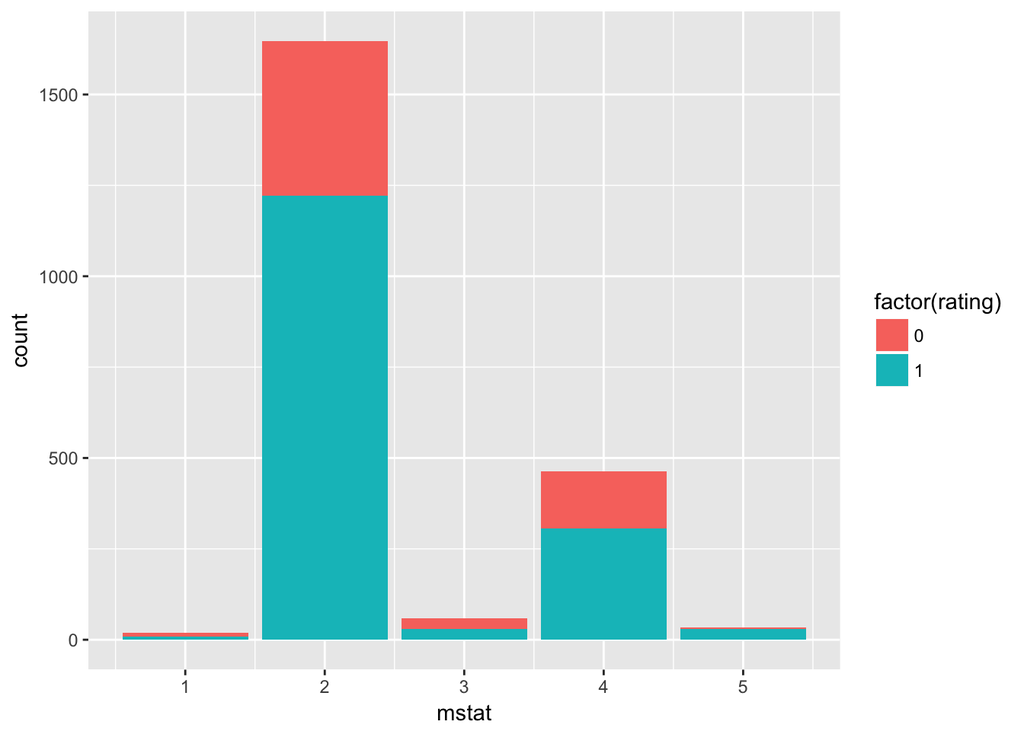

```r
ggplot(mydf_train, aes(mstat)) + geom_bar(aes(fill=factor(rating)))
```

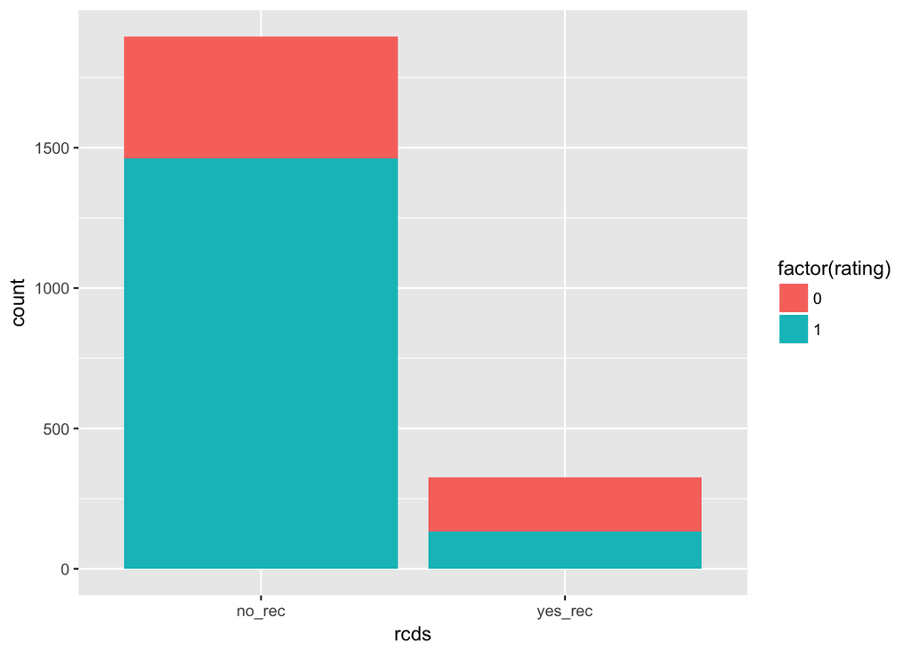

```r
ggplot(mydf_train, aes(rcds)) + geom_bar(aes(fill=factor(rating)))
```

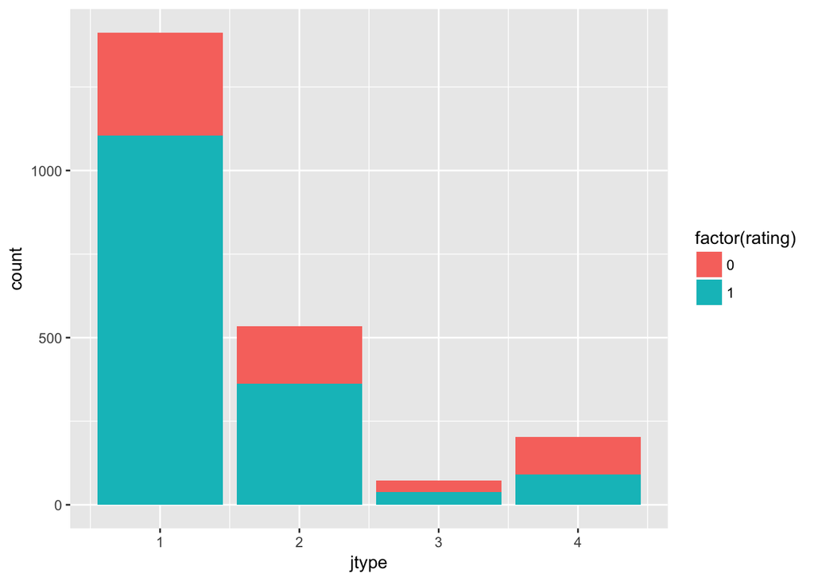

```r
ggplot(mydf_train, aes(jtype)) + geom_bar(aes(fill=factor(rating)))
```

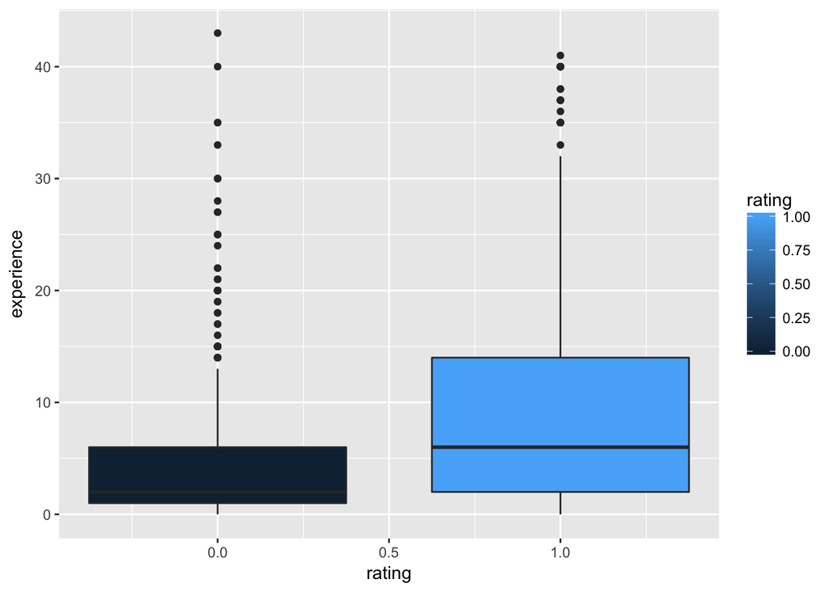

```r
#plot continuous~discrete varibales using boxplot
ggplot(mydf_train, aes(y=experience, x=rating,fill=rating, group=rating)) + geom_boxplot()
```

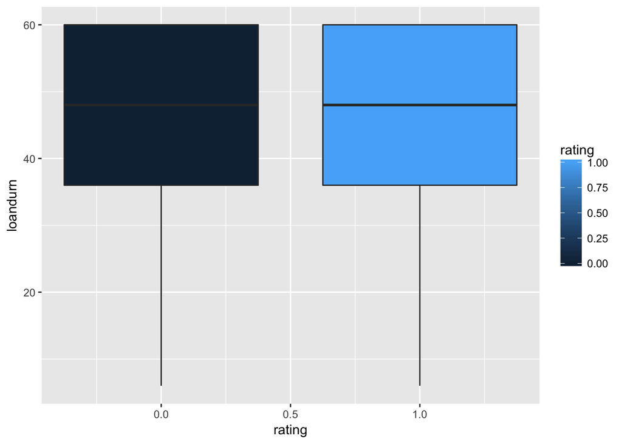

```r
ggplot(mydf_train, aes(y=loandurn, x=rating,fill=rating, group=rating)) + geom_boxplot()
```

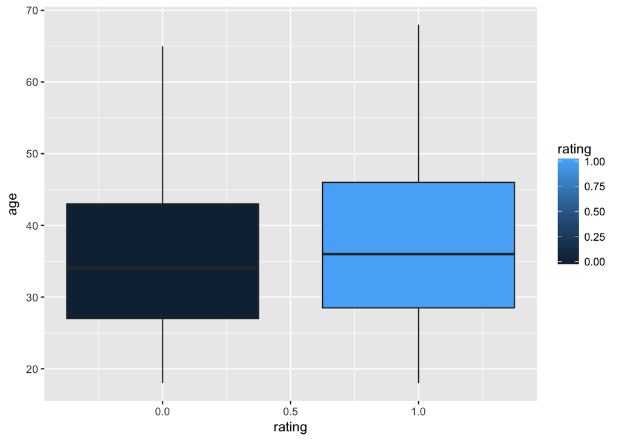

```r
ggplot(mydf_train, aes(y=age, x=rating,fill=rating, group=rating)) + geom_boxplot()
```

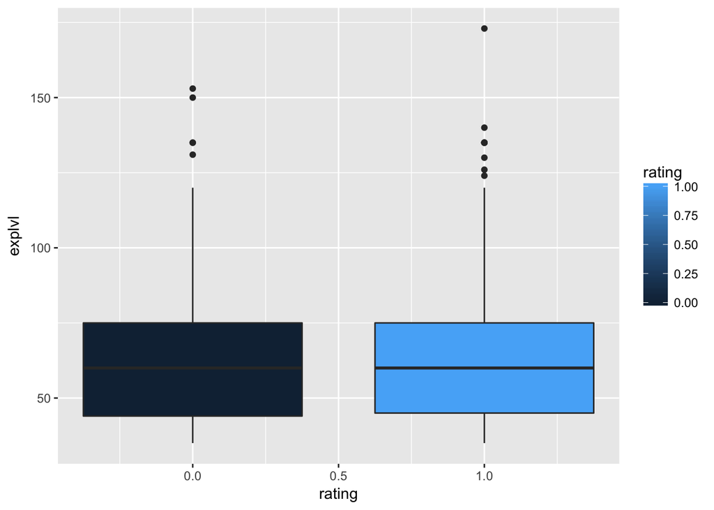

```r
ggplot(mydf_train, aes(y=explvl, x=rating,fill=rating, group=rating)) + geom_boxplot()
```

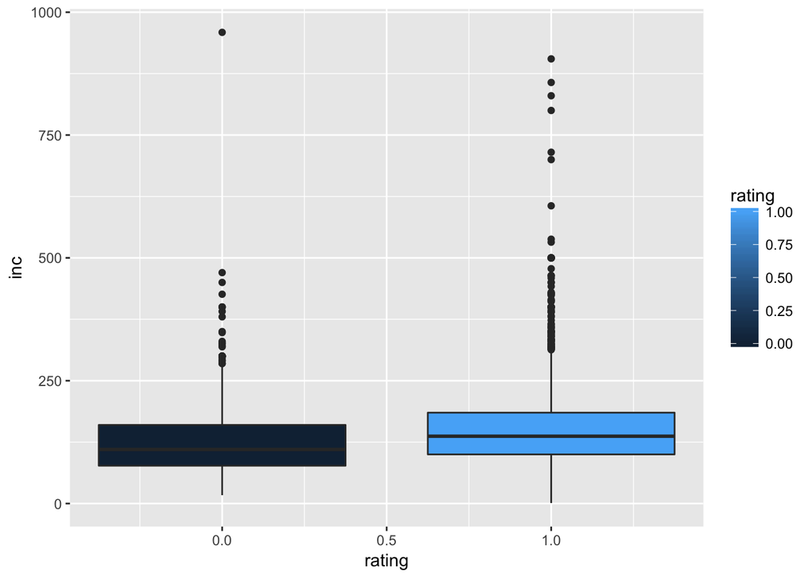

```r
ggplot(mydf_train, aes(y=inc, x=rating,fill=rating, group=rating)) + geom_boxplot()
```

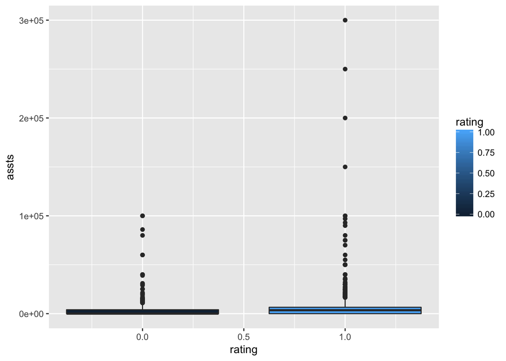

```r
ggplot(mydf_train, aes(y=assts, x=rating,fill=rating, group=rating)) + geom_boxplot()
```

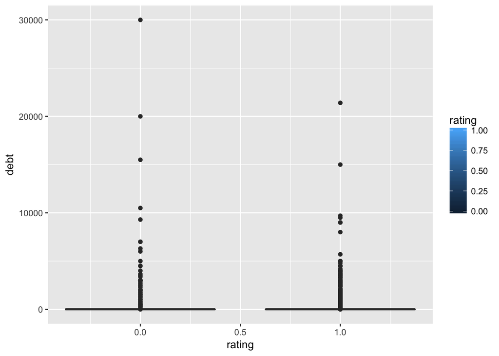

```r
ggplot(mydf_train, aes(y=debt, x=rating,fill=rating, group=rating)) + geom_boxplot()
```

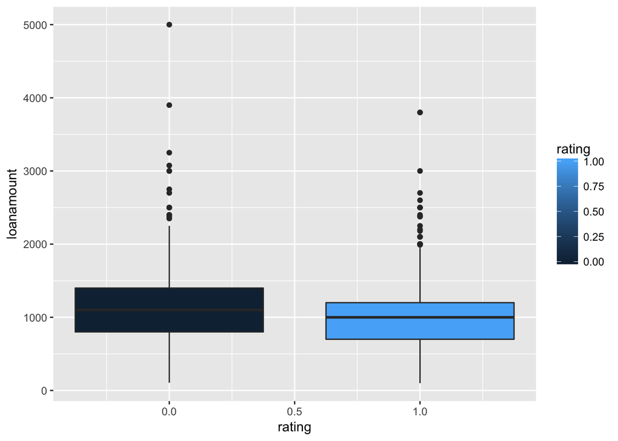

```r
ggplot(mydf_train, aes(y=loanamount, x=rating,fill=rating, group=rating)) + geom_boxplot()
```

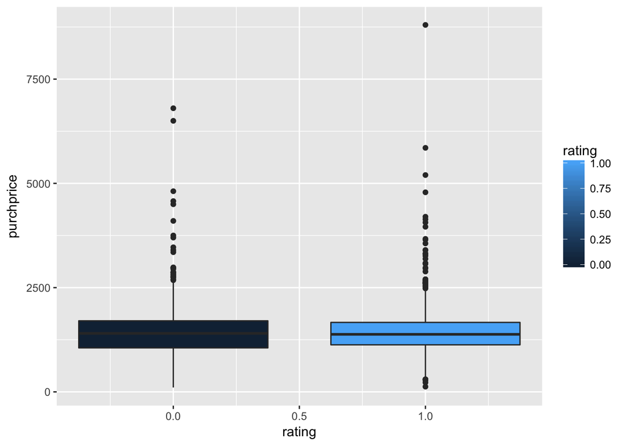

```r
ggplot(mydf_train, aes(y=purchprice, x=rating,fill=rating, group=rating)) + geom_boxplot()
```

#### There is nothing to inform me about a good predictor from these descriptives.

### Data Analysis

```r
library(dplyr)
str(mydf_train)    #View the training dataset
```

```
## 'data.frame':    2223 obs. of  14 variables:
##  $ rating    : num  1 1 0 1 1 1 1 1 1 0 ...
##  $ experience: int  9 17 10 0 0 1 29 9 0 0 ...
##  $ homeown   : num  6 6 3 6 6 3 3 4 3 4 ...
##  $ loandurn  : int  60 60 36 60 36 60 60 12 60 48 ...
##  $ age       : int  30 58 46 24 26 36 44 27 32 41 ...
##  $ mstat     : num  2 5 2 4 4 2 2 4 2 2 ...
##  $ rcds      : Factor w/ 2 levels "no_rec","yes_rec": 1 1 2 1 1 1 1 1 1 1 ...
##  $ jtype     : num  2 1 2 1 1 1 1 1 2 4 ...
##  $ explvl    : int  73 48 90 63 46 75 75 35 90 90 ...
##  $ inc       : int  129 131 200 182 107 214 125 80 107 80 ...
##  $ assts     : int  0 0 3000 2500 0 3500 10000 0 15000 0 ...
##  $ debt      : int  0 0 0 0 0 0 0 0 0 0 ...
##  $ loanamount: int  800 1000 2000 900 310 650 1600 200 1200 1200 ...
##  $ purchprice: int  846 1658 2985 1325 910 1645 1800 1093 1957 1468 ...
```

```r
model.logistic <- glm(formula = rating ~., family =binomial(link='logit'), data = mydf_train)   #fit a logistic regression model
summary(model.logistic)   #view the results contained in the model
```

```
##
## Call:
## glm(formula = rating ~ ., family = binomial(link = "logit"),
##     data = mydf_train)
##
## Deviance Residuals:
##     Min       1Q   Median       3Q      Max
## -3.1920  -0.7016   0.4351   0.7241   2.3941
##
## Coefficients:
##               Estimate Std. Error z value Pr(>|z|)
## (Intercept)  3.127e+00  5.234e-01   5.975 2.30e-09 ***
## experience   8.022e-02  1.011e-02   7.933 2.14e-15 ***
## homeown     -1.058e-01  4.275e-02  -2.474 0.013344 *
## loandurn    -7.717e-04  4.719e-03  -0.164 0.870096
## age         -1.004e-02  6.237e-03  -1.610 0.107385
## mstat       -1.667e-01  7.844e-02  -2.125 0.033568 *
## rcdsyes_rec -1.914e+00  1.493e-01 -12.824  < 2e-16 ***
## jtype       -4.429e-01  5.615e-02  -7.886 3.11e-15 ***
## explvl      -9.985e-03  3.521e-03  -2.836 0.004566 **
## inc          5.746e-03  8.616e-04   6.669 2.57e-11 ***
## assts        3.452e-05  9.655e-06   3.576 0.000349 ***
## debt        -1.708e-04  4.214e-05  -4.054 5.03e-05 ***
## loanamount  -2.057e-03  2.436e-04  -8.443  < 2e-16 ***
## purchprice   1.039e-03  1.859e-04   5.592 2.25e-08 ***
## ---
## Signif. codes:  0 '***' 0.001 '**' 0.01 '*' 0.05 '.' 0.1 ' ' 1
##
## (Dispersion parameter for binomial family taken to be 1)
##
##     Null deviance: 2646.7  on 2222  degrees of freedom
## Residual deviance: 2041.9  on 2209  degrees of freedom
## AIC: 2069.9
##
## Number of Fisher Scoring iterations: 5
```

#### According to summery of the model, all variables, except loandurn (loan duration) and age are significant

```r
model.logistic.fitted <- predict(model.logistic,mydf_test,type='response')    #apply the function predict to the model along with test dataset.
```

```r
# How good our model is
model.logistic.fitted <- ifelse(model.logistic.fitted > 0.5,1,0)   #if the predicted probability bigger than 0.5, the value will be replaced with 1, or else be replaced with 0.
misClassificationError <- mean(model.logistic.fitted != mydf_test$rating)  #calculate misclassificationerror which means the probability of wrong prediction
print(paste('Accuracy',1-misClassificationError))     #print the probability of accuracy
```

```
## [1] "Accuracy 0.792622582096266"
```

```r
library(rpart)
library(rpart.plot)
```

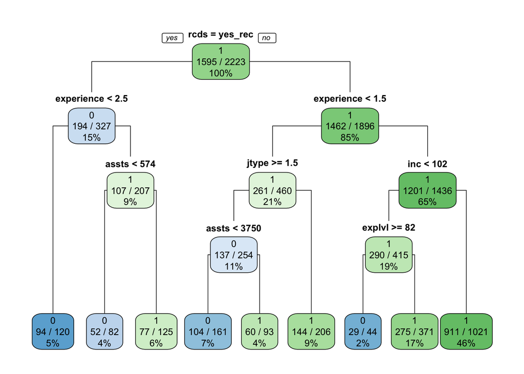

```r
#build up tree model and show the plot
model.tree <- rpart(rating ~ ., mydf_train, method = "class")
rpart.plot(model.tree, type=1, extra = 102)
```

#### This tree has splited 8 times. Each split is on one certain varible which has the biggest influcence on classification. For each branch, the “good” or “bad” is decided by the majority of this node; the fraction stands for the number of this kind majority; the percentage stands for the ratio of the number of this node to the overall number of this dataset.

#### The probability of all good rating customer is 1595/2223=71.75%. The biggest probability of good credit rating customers among all nodes is 911/1021 = 89.23% for those who don’t have existed records and job experience more than 1.5 years and level of income higher than 102.

## Part C

### (i) Please help your client understand which model is better for predicting purposes.

```r
library(ROCR)
```

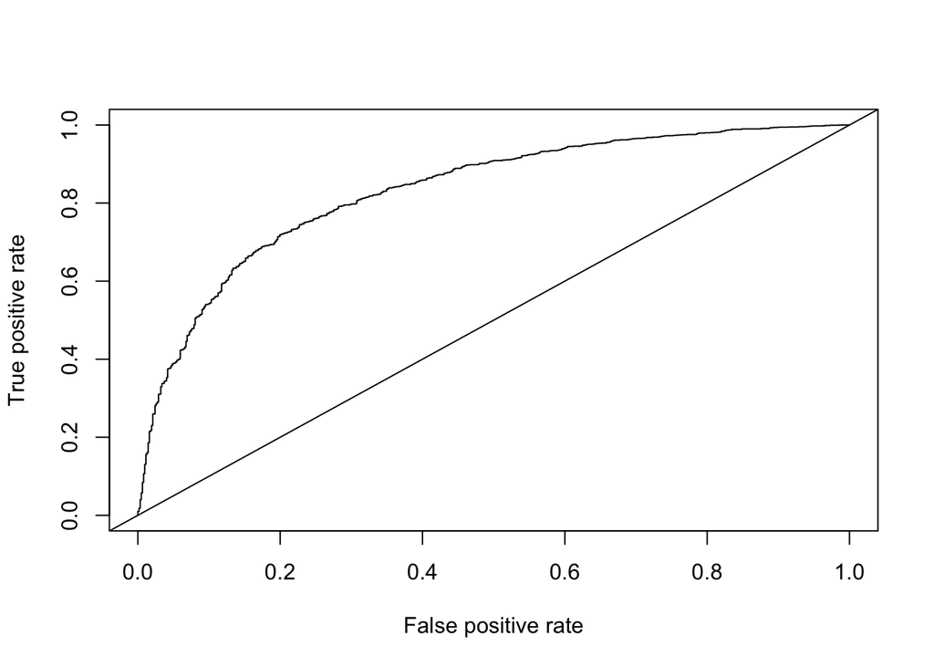

```r
#create a variable p assigned by returns of function predict
p <- predict(model.logistic, mydf_test, type="response")

#create a variable pr assigned by returns of function prediction
#prediction function is to transform p and rating into a format
pr <- prediction(p, mydf_test$rating)

# Y-axis = Sensitivity
# Sensitivity - the proportion of true positives
# X-axis = 1 - Specificity
# 1 - Specificity - the proportion of false positive
prf <- performance(pr, measure = "tpr", x.measure = "fpr")
plot(prf)
abline(a=0, b= 1)
```

```r
# The area under the ROC curve ( AUC ) is a measure of how well a parameter
auc <- performance(pr, measure = "auc")
auc <- auc@y.values[[1]]
auc
```

```
## [1] 0.8309551
```

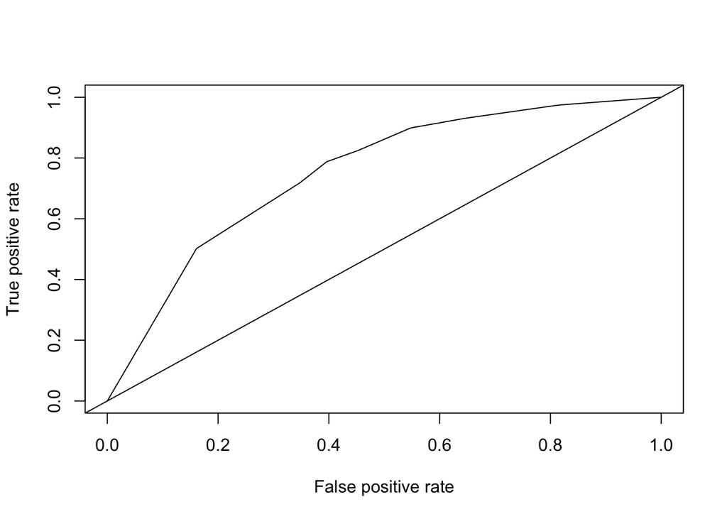

```r
probs <- predict(model.tree, mydf_test, type = "prob")[,2]
# Create a prediction object: pred
pred <- prediction(probs, mydf_test$rating)

# Make a performance object: perf
perf <- performance(pred, "tpr" , "fpr")

# Plot this curve
plot(perf)
abline(a=0, b= 1)
```

```r
auc <- performance(pred, measure = "auc")
auc <- auc@y.values[[1]]
auc
```

```
## [1] 0.7518058
```

#### The logistics regression model is better, because the auc value of logistics regression model is bigger than that of tree model.

### (ii) Find a way to explain sensitivity, specificity and auc in the ROC to your client (in less than 250 words).

#### The sensitivity is the probability of true positive. The concept of true positive means the model we use predicts correctly customer “good” given that the customer is actually “good”.

#### The specificity is the probability of true negative. The concept of true negative means the model we use predicts correctly customer “bad” given that the customer is actually “bad”.

#### The concept auc in the ROC means the “area under curve”, indicating whether the model is better than random 50/50 model. Because the random 50/50 model has a auc 0.5. The greater auc is, the better model fits. So as long as auc > 0.5, the model is better than random 50/50 model.

### (iii) Provide a brief write-up of your findings. How will you present these findings to your clients in less than 250 words?

#### The decision tree model also has the capability to predict dependent varaible. The probability of all good rating customer is 71.75%. The biggest probability of good credit rating customers among all nodes is 89.23% for those who don’t have existed records and job experience more than 1.5 years and level of income higher than 102.

#### Compared with the decision tree model, the logistics regression model for this dataset is more credible by ROC curve(AUC).